# Ggformula

13 juin 2019

## Un foisonnement de fonctions graphiques dans R

- Des fonctions intégrées de base (package graphics): barplot,plot
- Des packages dédiés :  
  ggplot2  
  lattice (représentations de données multivariées)  
  plotly (représentations interactives) etc.

## Ggplot2: la référence

- **Ggplot2**, package de référence développé par H. Wickham.
- Logique: considérer un graphique comme un cadre auquel viennent s'ajouter des "couches" successives.
- Un exemple de syntaxe:

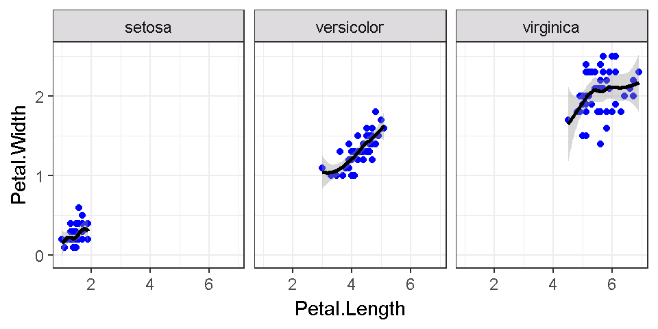

```r
ggplot(data=iris)+geom_point(color="Blue",aes(x=Petal.Length,y=Petal.Width))+
  geom_smooth(color="Black",aes(x=Petal.Length,y=Petal.Width))+
  facet_grid(~Species)+theme_bw()
```

## Ggplot2: la référence

->Une syntaxe très (trop) riche pour le profane

## Une alternative : ggformula

- Le package **ggformula** offre une surcouche à **ggplot**. Il unifie l'appel à des fonctions graphiques de manière simplifiée
- Ce package est promu à l'occasion des formations R à l'Insee
- Principe général: **objectif(y~x,data=mes_donnees)**
- L'appel d'une fonction ggformula crée simultanément un cadre et une couche de base
- Possibilité d'utiliser le pipe "%>%" pour combiner des instructions

## Quelques exemples de graphiques : le nuage de points

- avec ggformula:

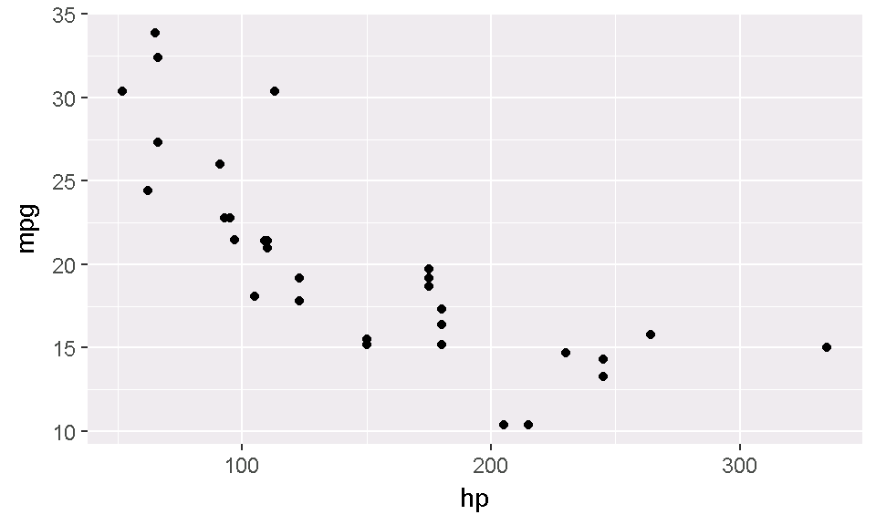

```r
library(ggformula)
gf_point(mpg~hp,data=mtcars)
```

## Quelques exemples de graphiques : le nuage de points

- avec ggplot2:

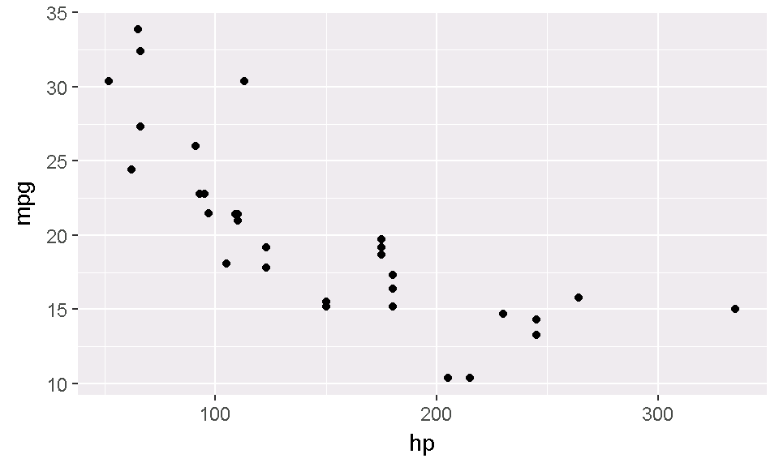

```r
library(ggplot2)
ggplot(data=mtcars)+geom_point(aes(hp,mpg))
```

## Quelques exemples de graphiques : l'histogramme

- avec ggformula:

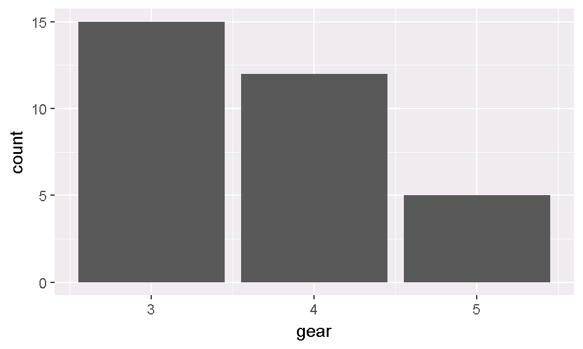

```r
library(ggformula)
gf_bar(~gear,data = mtcars)
```

## Quelques exemples de graphiques : l'histogramme

- avec ggplot2:

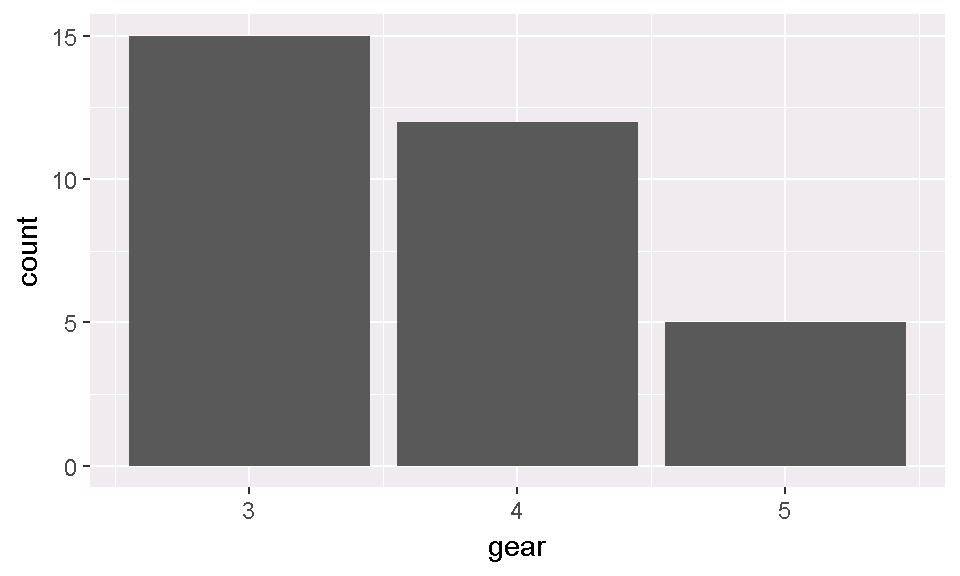

```r
library(ggplot2)
ggplot(data=mtcars)+geom_bar(aes(gear))
```

## Pour aller plus loin dans les représentations graphiques

Possibilité de faire varier une caractéristique des élements visualisés en fonction d'une variable (couleur, forme)  
* Exemple :

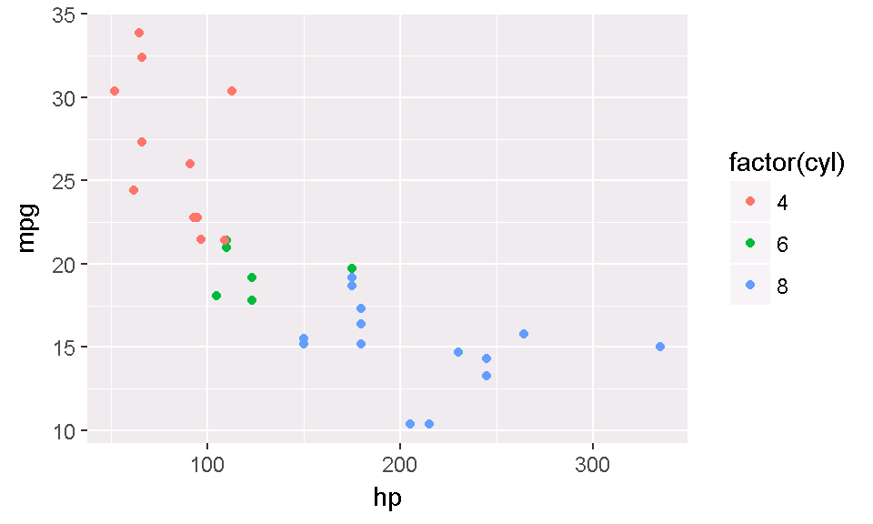

```r
gf_point(mpg~hp,data=mtcars,color=~factor(cyl))
```

## Pour aller plus loin dans les représentations graphiques

Possibilité de présenter plusieurs graphes dans une même figure (facetting) * Exemple :

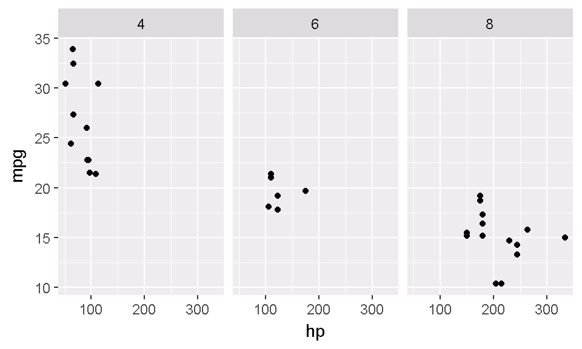

```r
gf_point(mpg~hp|factor(cyl),data=mtcars)
```

```r
#Possible de le faire également avec la fonction gf_facet_wrap()
```

## Ajustements des éléments graphiques

Il est possible de modifier différents éléments du graphique (limites des axes,échelles,thèmes) à l'aide des fonctions :

- gf_labs
- gf_lims
- gf_theme
- et pour tout le reste: gf_refine

## Ajustements des éléments graphiques

- Renommage d'un libellé de légende

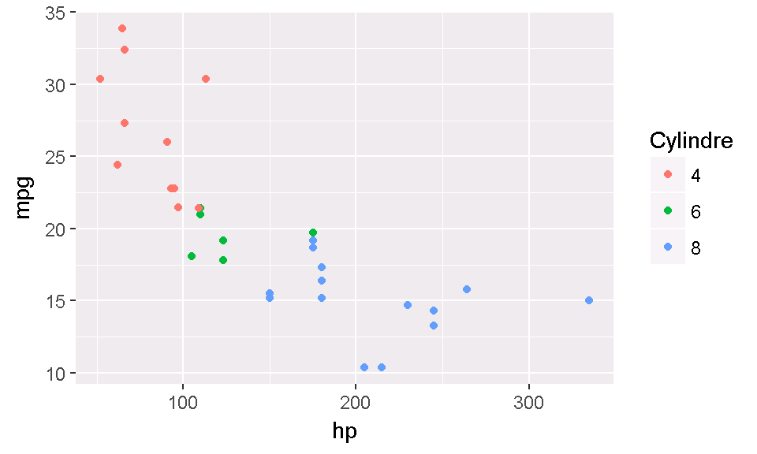

```r
mtcars$cyl=as.factor(mtcars$cyl)
gf_point(mpg~hp,data=mtcars,color=~cyl) %>% gf_labs(color="Cylindre")
```

## Ajustements des éléments graphiques

- Exemple de modification des libellés des axes…

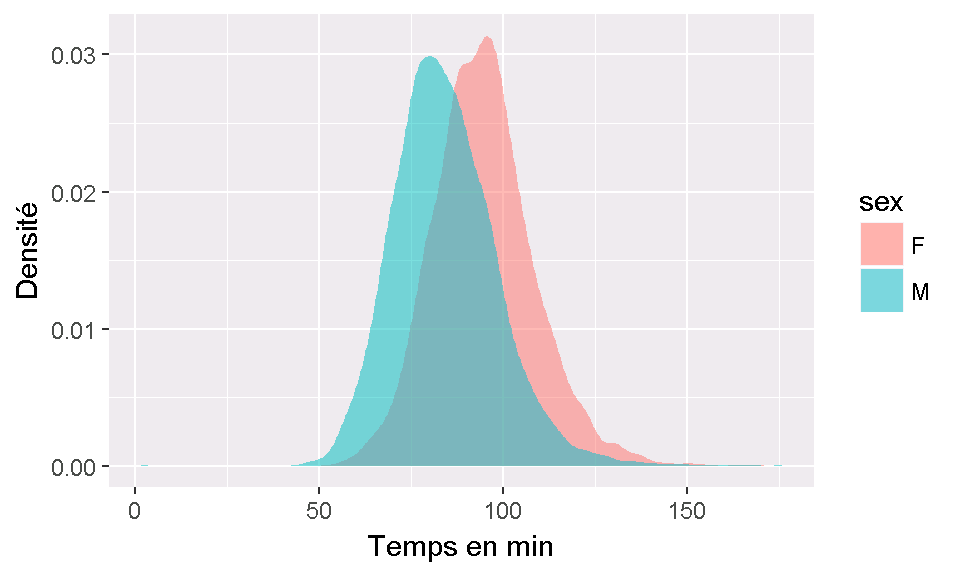

```r
data(Runners, package = "mosaicModel")
gf_density(~net,fill=~sex,data=Runners)%>%
  gf_labs(y="Densité",x="Temps en min")
```

## Ajustements des éléments graphiques

…et de la graduation d'un axe :

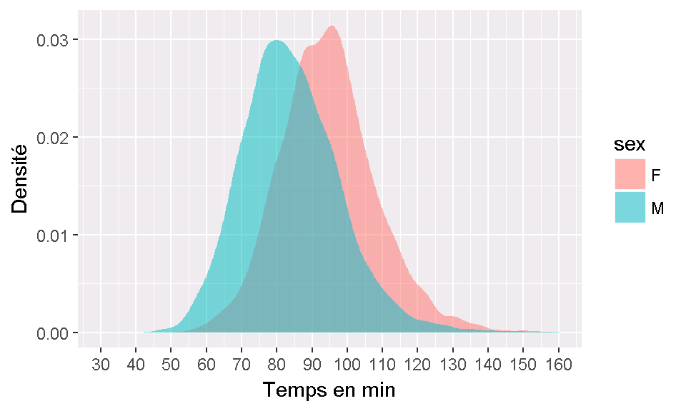

```r
gf_density(~net,fill=~sex,data=Runners)%>%
  gf_labs(y="Densité",x="Temps en min") %>%
  gf_refine(scale_x_continuous(breaks=seq(from=30, to = 160, by= 10),
                               limits = c(30,160)))
```

## Ajustements des éléments graphiques

- Exemple de modification d'une légende :

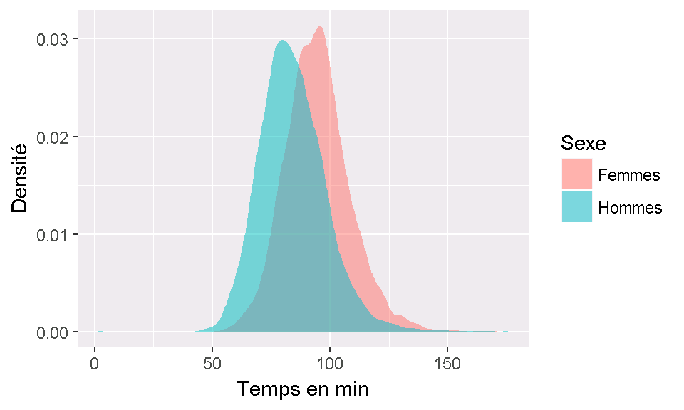

```r
gf_density(~net,fill=~sex,data=Runners)%>%
  gf_labs(y="Densité",x="Temps en min")%>%
  gf_refine(scale_fill_discrete(name="Sexe",labels=c("Femmes","Hommes")))
```

## Pour aller plus loin

Il est possible de créer des graphiques interactifs à l'aide du package plotly

```r
library(plotly)
gf_violin(net~sex,data=Runners)%>%gf_labs(y="Temps en min",x="Sexe")%>%
  ggplotly(tooltip="density")
```

[interactive chart not shown]